# Prosper Loan Data

## Preliminary Wrangling

> My dataset is the Prosper Loan Data. There are 113,937 rows of loans and 81 variables. I will look into about 20 variables. I wanted to explore how the market loan company's data and find insights related to the borrowers, the loan they lend and the grade represents the borrower's credit score, annual income, and among other things.

```python
# import all packages and set plots to be embedded inline
import numpy as np
import pandas as pd
import matplotlib.pyplot as plt
import seaborn as sb
import seaborn as sns
import matplotlib.patches as mpatches

%matplotlib inline
```

```python
#load in the dataset into a pandas dataframe, print statistics
prosperLoanData = pd.read_csv('prosperLoanData.csv')
```

```python
#high level overview of data shape and composition
print(prosperLoanData.shape)
print(prosperLoanData.dtypes)
print(prosperLoanData.head(10))
```

```
(113937, 81)
ListingKey                              object
ListingNumber                            int64
ListingCreationDate                     object
CreditGrade                             object
Term                                     int64
LoanStatus                              object
ClosedDate                              object
BorrowerAPR                            float64
BorrowerRate                           float64
LenderYield                            float64
EstimatedEffectiveYield                float64
EstimatedLoss                          float64
EstimatedReturn                        float64
ProsperRating (numeric)                float64
ProsperRating (Alpha)                   object
ProsperScore                           float64
ListingCategory (numeric)                int64
BorrowerState                           object
Occupation                              object
EmploymentStatus                        object
EmploymentStatusDuration               float64
IsBorrowerHomeowner                       bool
CurrentlyInGroup                          bool
GroupKey                                object
DateCreditPulled                        object
CreditScoreRangeLower                  float64
CreditScoreRangeUpper                  float64
FirstRecordedCreditLine                 object
CurrentCreditLines                     float64
OpenCreditLines                        float64
                                        ...
TotalProsperLoans                      float64
TotalProsperPaymentsBilled             float64
OnTimeProsperPayments                  float64
ProsperPaymentsLessThanOneMonthLate    float64
ProsperPaymentsOneMonthPlusLate        float64
ProsperPrincipalBorrowed               float64
ProsperPrincipalOutstanding            float64
ScorexChangeAtTimeOfListing            float64
```

[output cut: 81 more lines]

```
9                0                          0                         0.0

  Investors
0       258
1         1
2        41
3       158
4        20
5         1
6         1
7         1
8         1
9         1

[10 rows x 81 columns]
```

```python
#descriptive statistics for numeric variables
print(prosperLoanData.describe())
```

```
       ListingNumber           Term    BorrowerAPR   BorrowerRate  \
count   1.139370e+05  113937.000000  113912.000000  113937.000000
mean    6.278857e+05      40.830248       0.218828       0.192764
std     3.280762e+05      10.436212       0.080364       0.074818
min     4.000000e+00      12.000000       0.006530       0.000000
25%     4.009190e+05      36.000000       0.156290       0.134000
50%     6.005540e+05      36.000000       0.209760       0.184000
75%     8.926340e+05      36.000000       0.283810       0.250000
max     1.255725e+06      60.000000       0.512290       0.497500

         LenderYield  EstimatedEffectiveYield  EstimatedLoss  EstimatedReturn  \
count  113937.000000             84853.000000   84853.000000     84853.000000
mean        0.182701                 0.168661       0.080306         0.096068
std         0.074516                 0.068467       0.046764         0.030403
min        -0.010000                -0.182700       0.004900        -0.182700
25%         0.124200                 0.115670       0.042400         0.074080
50%         0.173000                 0.161500       0.072400         0.091700
75%         0.240000                 0.224300       0.112000         0.116600
max         0.492500                 0.319900       0.366000         0.283700

       ProsperRating (numeric)  ProsperScore      ...        LP_ServiceFees  \
count             84853.000000  84853.000000      ...         113937.000000
mean                  4.072243      5.950067      ...            -54.725641
std                   1.673227      2.376501      ...             60.675425
min                   1.000000      1.000000      ...           -664.870000
25%                   3.000000      4.000000      ...            -73.180000
50%                   4.000000      6.000000      ...            -34.440000
75%                   5.000000      8.000000      ...            -13.920000
max                   7.000000     11.000000      ...             32.060000

       LP_CollectionFees  LP_GrossPrincipalLoss  LP_NetPrincipalLoss  \
count      113937.000000          113937.000000        113937.000000
mean          -14.242698             700.446342           681.420499
std           109.232758            2388.513831          2357.167068
min         -9274.750000             -94.200000          -954.550000
25%             0.000000               0.000000             0.000000
50%             0.000000               0.000000             0.000000
75%             0.000000               0.000000             0.000000
max             0.000000           25000.000000         25000.000000

       LP_NonPrincipalRecoverypayments  PercentFunded  Recommendations  \
count                    113937.000000  113937.000000    113937.000000
mean                         25.142686       0.998584         0.048027
std                         275.657937       0.017919         0.332353
min                           0.000000       0.700000         0.000000
25%                           0.000000       1.000000         0.000000
50%                           0.000000       1.000000         0.000000
75%                           0.000000       1.000000         0.000000
max                       21117.900000       1.012500        39.000000

       InvestmentFromFriendsCount  InvestmentFromFriendsAmount      Investors
count               113937.000000                113937.000000  113937.000000
mean                     0.023460                    16.550751      80.475228
std                      0.232412                   294.545422     103.239020
min                      0.000000                     0.000000       1.000000
25%                      0.000000                     0.000000       2.000000
50%                      0.000000                     0.000000      44.000000
75%                      0.000000                     0.000000     115.000000
max                     33.000000                 25000.000000    1189.000000

[8 rows x 61 columns]
```

```python
prosperLoanData.info()
```

```
<class 'pandas.core.frame.DataFrame'>
RangeIndex: 113937 entries, 0 to 113936
Data columns (total 81 columns):
ListingKey                             113937 non-null object
ListingNumber                          113937 non-null int64
ListingCreationDate                    113937 non-null object
CreditGrade                            28953 non-null object
Term                                   113937 non-null int64
LoanStatus                             113937 non-null object
ClosedDate                             55089 non-null object
BorrowerAPR                            113912 non-null float64
BorrowerRate                           113937 non-null float64
LenderYield                            113937 non-null float64
EstimatedEffectiveYield                84853 non-null float64
EstimatedLoss                          84853 non-null float64
EstimatedReturn                        84853 non-null float64
ProsperRating (numeric)                84853 non-null float64
ProsperRating (Alpha)                  84853 non-null object
ProsperScore                           84853 non-null float64
ListingCategory (numeric)              113937 non-null int64
BorrowerState                          108422 non-null object
Occupation                             110349 non-null object
EmploymentStatus                       111682 non-null object
EmploymentStatusDuration               106312 non-null float64
IsBorrowerHomeowner                    113937 non-null bool
CurrentlyInGroup                       113937 non-null bool
GroupKey                               13341 non-null object
DateCreditPulled                       113937 non-null object
CreditScoreRangeLower                  113346 non-null float64
CreditScoreRangeUpper                  113346 non-null float64
FirstRecordedCreditLine                113240 non-null object
CurrentCreditLines                     106333 non-null float64
OpenCreditLines                        106333 non-null float64
TotalCreditLinespast7years             113240 non-null float64
OpenRevolvingAccounts                  113937 non-null int64
OpenRevolvingMonthlyPayment            113937 non-null int64
InquiriesLast6Months                   113240 non-null float64
TotalInquiries                         112778 non-null float64
CurrentDelinquencies                   113240 non-null float64
AmountDelinquent                       106315 non-null float64
```

[output cut: 31 more lines]

```
LP_CustomerPayments                    113937 non-null float64
LP_CustomerPrincipalPayments           113937 non-null float64
LP_InterestandFees                     113937 non-null float64
LP_ServiceFees                         113937 non-null float64
LP_CollectionFees                      113937 non-null float64
LP_GrossPrincipalLoss                  113937 non-null float64
LP_NetPrincipalLoss                    113937 non-null float64
LP_NonPrincipalRecoverypayments        113937 non-null float64
PercentFunded                          113937 non-null float64
Recommendations                        113937 non-null int64
InvestmentFromFriendsCount             113937 non-null int64
InvestmentFromFriendsAmount            113937 non-null float64
Investors                              113937 non-null int64
dtypes: bool(3), float64(49), int64(12), object(17)
memory usage: 68.1+ MB
```

### What is the structure of your dataset?

> The dataset contains 113,937 loans with 81 variables. The loan listings are from late 2005 - 2014 with various characteristics of those loans. I selected 21 variables out of 81 and they are consisting of 10 discrete variables and 11 continuous variables.

> Discrete Variables: LoanOriginationQuarter, ListingCategory, EmploymentStatus, IsBorrowerHomeowner, CreditGrade, IncomeRange, IncomeVerifiable, BorrowerState, Occupation, Term.

> Continuous Variables: LoanOriginalAmount, MonthlyLoanPayment, BorrowerRate, BorrowerAPR, DebtToIncomeRation, CreditScoreRangeLower, CreditScoreRangeUpper, StatedMonthlyIncome, EmploymentStatusDuration, ProsperRating, ProsperScore.

### What is/are the main feature(s) of interest in your dataset?

> I am most interested to see the Loan Origination Quarter and how the market loan company's data and find insights related to the borrowers, the loan they lend and the grade represents the borrower's credit score, annual income, and among other things.

### What features in the dataset do you think will help support your investigation into your feature(s) of interest?

> My main investigation will be into how the borrower's characteristics changed overtime as its business model and the larger lending environment evolved. The Loan Origination Quarter is critical feature base line.

## Univariate Exploration

First, I want to see the loan origination quarter.

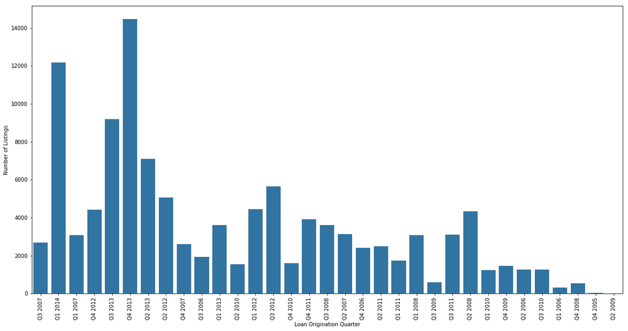

```python
#univariate plot of loan origination quarter
plt.figure(figsize=(20,10))
base_color = sb.color_palette()[0]
sb.countplot(data = prosperLoanData , x = 'LoanOriginationQuarter', color=base_color)
plt.xlabel('Loan Origination Quarter')
plt.ylabel('Number of Listings')
plt.xticks(rotation=90);
```

This is hard to understand the trend in this order level so I will re-plot it in categorical type to display date series order.

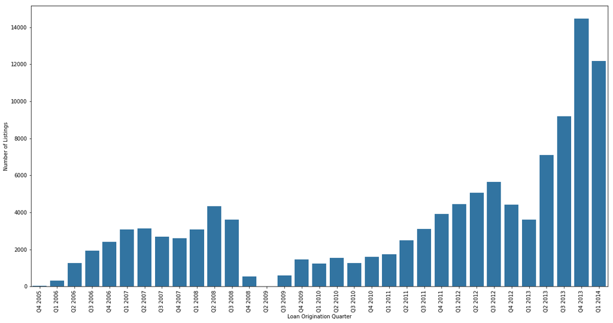

```python
#univariate plot of loan origination quarter in an order categorical type
quarter = ['Q4 2005', 'Q1 2006', 'Q2 2006', 'Q3 2006', 'Q4 2006', 'Q1 2007', 'Q2 2007', 'Q3 2007', 'Q4 2007', 'Q1 2008', 'Q2 2008', 'Q3 2008', 'Q4 2008',
          'Q2 2009', 'Q3 2009', 'Q4 2009', 'Q1 2010', 'Q2 2010', 'Q3 2010', 'Q4 2010', 'Q1 2011', 'Q2 2011', 'Q3 2011', 'Q4 2011', 'Q1 2012', 'Q2 2012', 'Q3 2012', 'Q4 2012',
          'Q1 2013', 'Q2 2013', 'Q3 2013', 'Q4 2013', 'Q1 2014']
qrt_cat = pd.api.types.CategoricalDtype(ordered = True, categories = quarter)
prosperLoanData['LoanOriginationQuarter'] = prosperLoanData['LoanOriginationQuarter'].astype(qrt_cat)

prosperLoanData = prosperLoanData.loc[prosperLoanData['LoanOriginationQuarter'].isin(['Q4 2005', 'Q1 2006', 'Q2 2006', 'Q3 2006', 'Q4 2006', 'Q1 2007', 'Q2 2007', 'Q3 2007', 'Q4 2007', 'Q1 2008', 'Q2 2008', 'Q3 2008', 'Q4 2008',
          'Q2 2009', 'Q3 2009', 'Q4 2009', 'Q1 2010', 'Q2 2010', 'Q3 2010', 'Q4 2010', 'Q1 2011', 'Q2 2011', 'Q3 2011', 'Q4 2011', 'Q1 2012', 'Q2 2012', 'Q3 2012', 'Q4 2012',
          'Q1 2013', 'Q2 2013', 'Q3 2013', 'Q4 2013', 'Q1 2014'])]

plt.figure(figsize=(20,10))
base_color = sb.color_palette()[0]
ax=sb.countplot(data=prosperLoanData, x='LoanOriginationQuarter', color=base_color)
plt.xlabel('Loan Origination Quarter')
plt.ylabel('Number of Listings')
plt.xticks(rotation=90);
```

What a huge difference it makes. By looking at this graph, it took 3 years for listing levels to reach the Q2 2008. Then, there is a big dip from Q4 2008 - 2009. After doing some research on Wikipedia, this time period concurs with the fall of the market in Fall 2008 with the huge effect by the collapse of the major investment firm Lehman Brothers and, the succeeding fallout in the global financial system. It appears the Prosper business was susceptible to the global economic crisis. We'll explore more data with the LOQ later at the Bivariate.

Let's check the loans amount.

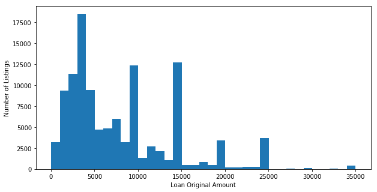

```python
#univariate plot of loan original amount
plt.figure(figsize=(10,5))
bins = np.arange(20, prosperLoanData['LoanOriginalAmount'].max()+1000,1000)
plt.hist(prosperLoanData['LoanOriginalAmount'], bins = bins)
plt.xlabel('Loan Original Amount')
plt.ylabel('Number of Listings');
```

```python
#check the average loan amount
prosperLoanData['LoanOriginalAmount'].describe()
```

```
count    113937.00000
mean       8337.01385
std        6245.80058
min        1000.00000
25%        4000.00000
50%        6500.00000
75%       12000.00000
max       35000.00000
Name: LoanOriginalAmount, dtype: float64
```

The loan amounts skew relatively small, with the median of 6,500 dollars less than mean of $8,337.

It is interesting to see what type of loans contributed in less than $10,000. Let's check this one next.

```python
#first i would like to rename ListingCategory (numeric) to ListingCategory
prosperLoanData=prosperLoanData.rename(columns = {'ListingCategory (numeric)':'ListingCategory'})
```

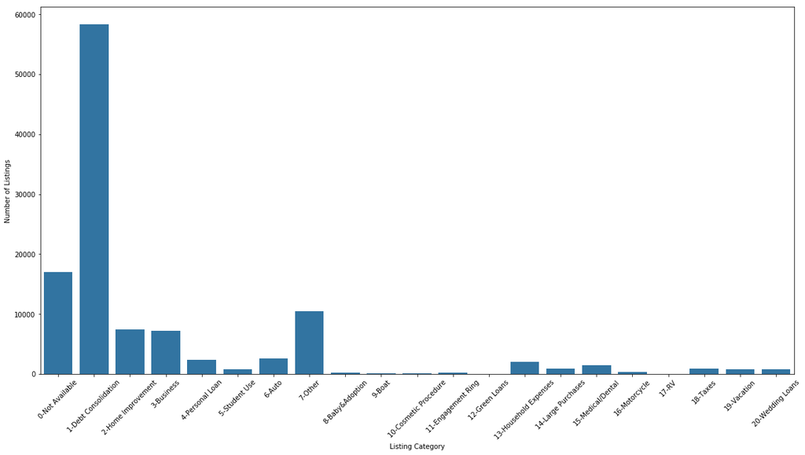

```python
#univariate plot of listing category, create xstick labels
plt.figure(figsize=(20,10))
g = sb.countplot(data = prosperLoanData, x = 'ListingCategory', color = base_color)
plt.xlabel('Listing Category')
plt.ylabel('Number of Listings')
xlabels = ['0-Not Available', '1-Debt Consolidation', '2-Home Improvement', '3-Business', '4-Personal Loan', '5-Student Use', '6-Auto', '7-Other', '8-Baby&Adoption', '9-Boat', '10-Cosmetic Procedure', '11-Engagement Ring', '12-Green Loans', '13-Household Expenses', '14-Large Purchases', '15-Medical/Dental', '16-Motorcycle', '17-RV', '18-Taxes', '19-Vacation', '20-Wedding Loans']
g.set_xticklabels(xlabels, rotation=45);
```

```python
#check listing category counts
prosperLoanData['ListingCategory'].value_counts()
```

```
1     58308
0     16965
7     10494
2      7433
3      7189
6      2572
4      2395
13     1996
15     1522
18      885
14      876
20      771
19      768
5       756
16      304
11      217
8       199
10       91
9        85
12       59
17       52
Name: ListingCategory, dtype: int64
```

The most loans are category 1-Debt Consolidation. Based on the loan amount distribution, a typical loan is for consolidating less than $10K of debt is more likely credit card debt.

What are the loans appraised for?

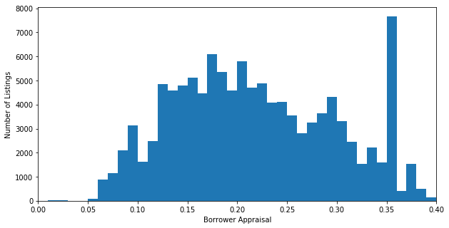

```python
# univariate plot of borrower appraisal on a standard scale
binsize = 0.01
bins = np.arange(0, prosperLoanData ['BorrowerAPR'].max()+binsize, binsize)

plt.figure(figsize=[10, 5])
plt.hist(data = prosperLoanData, x = 'BorrowerAPR', bins = bins)
plt.xlim([0,0.4])
plt.xlabel('Borrower Appraisal')
plt.ylabel('Number of Listings')
plt.show()
```

```python
#check the average borrower appraisal
prosperLoanData['BorrowerAPR'].describe()
```

```
count    113912.000000
mean          0.218828
std           0.080364
min           0.006530
25%           0.156290
50%           0.209760
75%           0.283810
max           0.512290
Name: BorrowerAPR, dtype: float64
```

The median appraisal rate is 20.97%. There is a large number of loans appraised over 35%.

What are the interest rates on these loans?

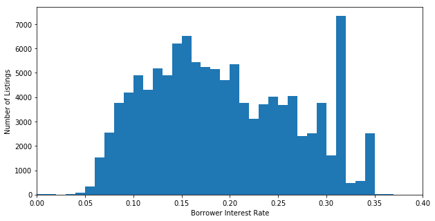

```python
# univariate plot of borrower rate on a standard scale
binsize = 0.01
bins = np.arange(0, prosperLoanData ['BorrowerRate'].max()+binsize, binsize)

plt.figure(figsize=[10, 5])
plt.hist(data = prosperLoanData, x = 'BorrowerRate', bins = bins)
plt.xlim([0,0.4])
plt.xlabel('Borrower Interest Rate')
plt.ylabel('Number of Listings')
plt.show()
```

```python
#check the average borrower rate
prosperLoanData['BorrowerRate'].describe()
```

```
count    113937.000000
mean          0.192764
std           0.074818
min           0.000000
25%           0.134000
50%           0.184000
75%           0.250000
max           0.497500
Name: BorrowerRate, dtype: float64
```

The interest rates are high, averaging 18% which is 2% less lower than the appraisal as expected. There are also spikes at higher interest rates over 30%. From previous loan category, the most loan is debt consolidation, these high rates must still be better than the interest rates the borrowers would have to pay to credit card companies. Or, could be the borrowers see value in freeing up the borrowing limit on their credit cards, even if it means paying high rates to Prosper lenders.

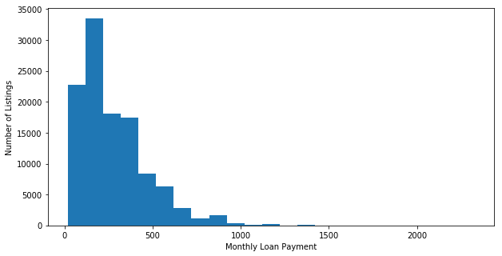

```python
#univariate plot of monthly loan payment
plt.figure(figsize=(10,5))
bins = np.arange(20, prosperLoanData['MonthlyLoanPayment'].max()+100, 100)
plt.hist(prosperLoanData['MonthlyLoanPayment'], bins = bins)
plt.xlabel('Monthly Loan Payment')
plt.ylabel('Number of Listings');
```

```python
prosperLoanData['MonthlyLoanPayment'].describe()
```

```
count    113937.000000
mean        272.475783
std         192.697812
min           0.000000
25%         131.620000
50%         217.740000
75%         371.580000
max        2251.510000
Name: MonthlyLoanPayment, dtype: float64
```

The distribution skews towards to smaller monthly payments and there are very few payments above 1,000 dollars. The payment >2k seems like a significant outlier. Let's take a closer look of the distribution, so let's put it on a log scale instead.

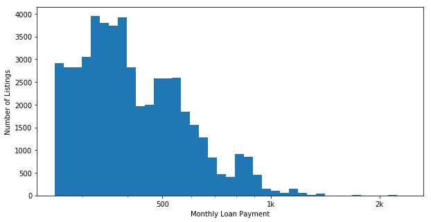

```python
#univariate plot of monthly loan payment on a log scale
log_binsize = 0.025
bins = 10 ** np.arange(2.4, np.log10(prosperLoanData['MonthlyLoanPayment'].max())+log_binsize, log_binsize)
plt.figure(figsize=[10, 5])
plt.hist(data = prosperLoanData, x = 'MonthlyLoanPayment', bins = bins)
plt.xscale('log')
plt.xticks([500, 1e3, 2e3], [500, '1k', '2k'])
plt.xlabel('Monthly Loan Payment')

plt.ylabel('Number of Listings')
plt.show()
```

The median monthly payment is 217 dollars. As you can see the distribution skews towards to smaller monthly payments. There are very few payments above 1,000 dollars. The payment >2k seems like a significant outlier. When plotted in a log scale, there's couple of peaks. One peak from 100 to 300, and a second peak below 600. There is a jump in frequency at 400, rather than a smooth ramp down.

What are the borrowers income?

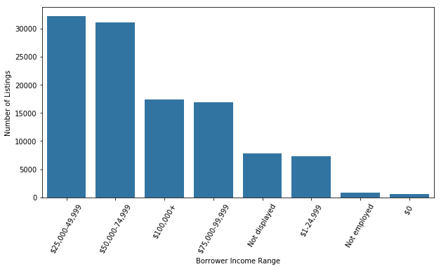

```python
#univariate plot income range
plt.figure(figsize=(10,5))
base_color = sb.color_palette()[0]
cat_order = prosperLoanData['IncomeRange'].value_counts().index
sb.countplot(data = prosperLoanData , x = 'IncomeRange', color = base_color, order = cat_order)
plt.xlabel('Borrower Income Range')
plt.ylabel('Number of Listings')
plt.xticks(rotation=60);
```

```python
#income verifiable
prosperLoanData['IncomeVerifiable'].value_counts()
```

```
True     105268
False      8669
Name: IncomeVerifiable, dtype: int64
```

The income ranges show the largest majority of borrowers make less than $75,000. This could be the reason why credit cards are maximized and needed to be consolidated. 92% are income verifiable.

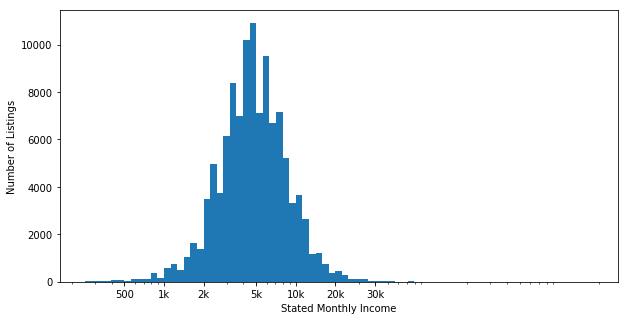

```python
#univariate plot of stated monthly income
log_binsize = 0.05
bins = 10 ** np.arange(2.4, np.log10(prosperLoanData['StatedMonthlyIncome'].max())+log_binsize, log_binsize)
plt.figure(figsize=[10, 5 ])
plt.hist(data = prosperLoanData, x = 'StatedMonthlyIncome', bins = bins)
plt.xscale('log')
plt.xticks([500, 1e3, 2e3, 5e3, 1e4, 2e4, 4e4], ['500', '1k', '2k', '5k', '10k', '20k', '30k'])
plt.xlabel('Stated Monthly Income')
plt.ylabel('Number of Listings')
plt.show()
```

```python
prosperLoanData['StatedMonthlyIncome'].describe()
```

```
count    1.139370e+05
mean     5.608026e+03
std      7.478497e+03
min      0.000000e+00
25%      3.200333e+03
50%      4.666667e+03
75%      6.825000e+03
max      1.750003e+06
Name: StatedMonthlyIncome, dtype: float64
```

Stated monthly income shows positive skew with mean of 5608 which is greater than median 4666.

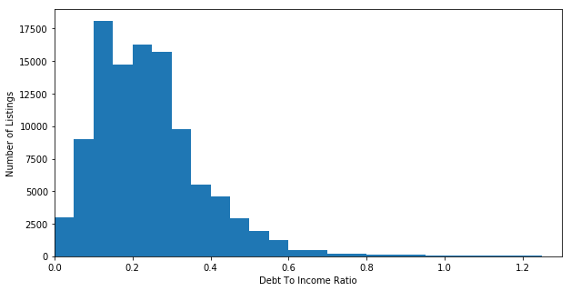

```python
#univariate plot of debt income ratio on a standard scale
binsize = 0.05
bins = np.arange(0, prosperLoanData ['DebtToIncomeRatio'].max()+binsize, binsize)

plt.figure(figsize=[10, 5])
plt.hist(data = prosperLoanData, x = 'DebtToIncomeRatio', bins = bins)
plt.xlim([0, 1.3])
plt.xlabel('Debt To Income Ratio')
plt.ylabel('Number of Listings')
plt.show()
```

```python
prosperLoanData ['DebtToIncomeRatio'].describe()
```

```
count    105383.000000
mean          0.275947
std           0.551759
min           0.000000
25%           0.140000
50%           0.220000
75%           0.320000
max          10.010000
Name: DebtToIncomeRatio, dtype: float64
```

Debt income ratio slight positive skew with majority are less than 0.5, not including the outliers on the high side on the right.

What are the borrowers credit grades depend on their debt to income ratio?

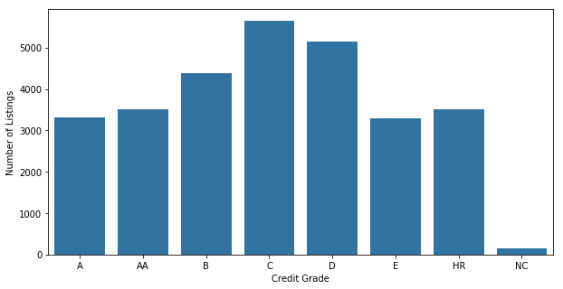

```python
#univariate plot of credit grade in an order categorical type
grade = ['A', 'AA', 'B', 'C', 'D', 'E', 'HR','NC']
grade_cat = pd.api.types.CategoricalDtype(ordered = True, categories = grade)
prosperLoanData['CreditGrade'] = prosperLoanData['CreditGrade'].astype(grade_cat)

prosperLoanData = prosperLoanData.loc[prosperLoanData['CreditGrade'].isin(['A', 'AA', 'B', 'C', 'D', 'E', 'HR','NC'])]

plt.figure(figsize=(10,5))
base_color = sb.color_palette()[0]
ax=sb.countplot(data=prosperLoanData, x='CreditGrade', color=base_color)
plt.xlabel('Credit Grade')
plt.ylabel('Number of Listings')
plt.xticks();
```

```python
prosperLoanData['CreditGrade'].value_counts()
```

```
C     5649
D     5153
B     4389
AA    3509
HR    3508
A     3315
E     3289
NC     141
Name: CreditGrade, dtype: int64
```

Credit grade C and D are running higher than grade A and B.

```python
prosperLoanData['ProsperRating (Alpha)'].value_counts()
```

```
C     18345
B     15581
A     14551
D     14274
E      9795
HR     6935
AA     5372
Name: ProsperRating (Alpha), dtype: int64
```

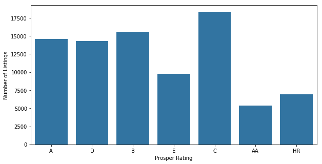

```python
#univariate plot of prosper rating
plt.figure(figsize=(10,5))
base_color = sb.color_palette()[0]
sb.countplot(data = prosperLoanData, x = 'ProsperRating (Alpha)', color = base_color)
plt.xlabel('Prosper Rating')
plt.ylabel('Number of Listings')
plt.show()
```

By looking at this graph, it looks like both most risky and less risky are normally distributed. I will re-order the category level to see if will show any progression.

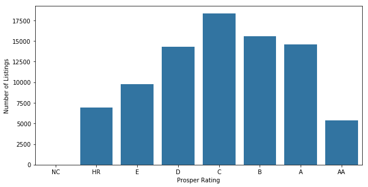

```python
#univariate plot of prosper rating in an order categorical type from riskiest to less risky
pros_rate = ['NC', 'HR', 'E', 'D', 'C', 'B', 'A','AA']
rate_cat = pd.api.types.CategoricalDtype(ordered = True, categories = pros_rate)
prosperLoanData['ProsperRating (Alpha)'] = prosperLoanData['ProsperRating (Alpha)'].astype(rate_cat)

prosperLoanData = prosperLoanData.loc[prosperLoanData['ProsperRating (Alpha)'].isin(['NC', 'HR', 'E', 'D', 'C', 'B', 'A','AA'])]

plt.figure(figsize=(10,5))
base_color = sb.color_palette()[0]
ax=sb.countplot(data=prosperLoanData, x='ProsperRating (Alpha)', color=base_color)
plt.xlabel('Prosper Rating')
plt.ylabel('Number of Listings')
plt.xticks();
```

This is better. I re-order the category level to show the progression of the riskiest to less risky (from left to right.)

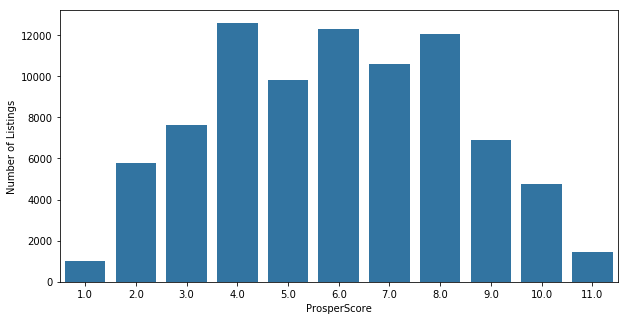

```python
#univariate plot of prosper score
plt.figure(figsize=(10,5))
base_color = sb.color_palette()[0]
sb.countplot(data = prosperLoanData, x = 'ProsperScore', color = base_color)
plt.xlabel('ProsperScore')
plt.ylabel('Number of Listings')
```

The prosper score is normally distributed. Risk ratings are relatively normal across the category.

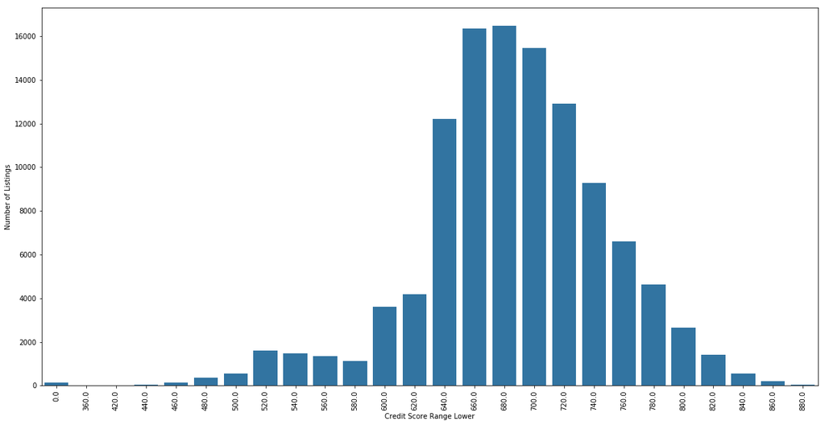

```python
#univariate plot of credit score range lower
plt.figure(figsize=(20,10))
base_color = sb.color_palette()[0]
sb.countplot(data = prosperLoanData , x = 'CreditScoreRangeLower', color = base_color)
plt.xlabel('Credit Score Range Lower')
plt.ylabel('Number of Listings')
plt.xticks(rotation=90);
```

```python
prosperLoanData['CreditScoreRangeLower'].describe()
```

```
count    84853.000000
mean       699.390240
std         47.095937
min        600.000000
25%        660.000000
50%        700.000000
75%        720.000000
max        880.000000
Name: CreditScoreRangeLower, dtype: float64
```

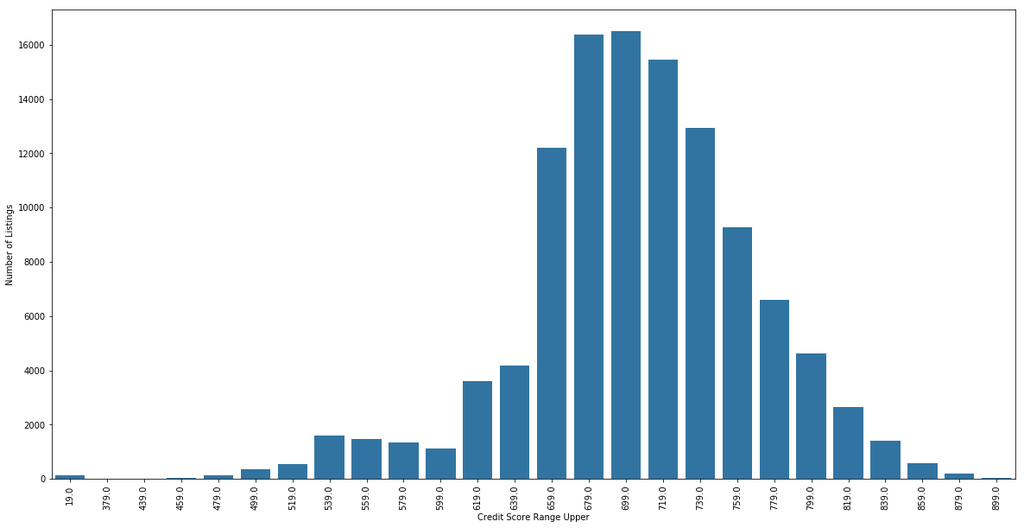

```python
#univariate plot of credit score range upper
plt.figure(figsize=(20,10))
base_color = sb.color_palette()[0]
sb.countplot(data = prosperLoanData , x = 'CreditScoreRangeUpper', color = base_color)
plt.xlabel('Credit Score Range Upper')
plt.ylabel('Number of Listings')
plt.xticks(rotation=90);
```

```python
prosperLoanData['CreditScoreRangeUpper'].describe()
```

```
count    113346.000000
mean        704.567731
std          66.458275
min          19.000000
25%         679.000000
50%         699.000000
75%         739.000000
max         899.000000
Name: CreditScoreRangeUpper, dtype: float64
```

Credit score range upper is normally distributed with mean/med = 704/699. Upper range has very similar distribution to Lower range but 19 points higher.

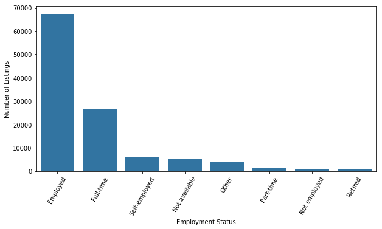

```python
#univariate plot of employment status
plt.figure(figsize=(10,5))
base_color = sb.color_palette()[0]
cat_order = prosperLoanData['EmploymentStatus'].value_counts().index
sb.countplot(data = prosperLoanData , x = 'EmploymentStatus', color = base_color, order = cat_order)
plt.xlabel('Employment Status')
plt.ylabel('Number of Listings')
plt.xticks(rotation=60);
```

```python
prosperLoanData['EmploymentStatus'].value_counts()
```

```
Employed         67310
Full-time         7927
Self-employed     4538
Other             3806
Not employed       649
Retired            367
Part-time          256
Name: EmploymentStatus, dtype: int64
```

```python
prosperLoanData['IsBorrowerHomeowner'].value_counts()
```

```
True     44848
False    40005
Name: IsBorrowerHomeowner, dtype: int64
```

What is the occupation of the borrowers?

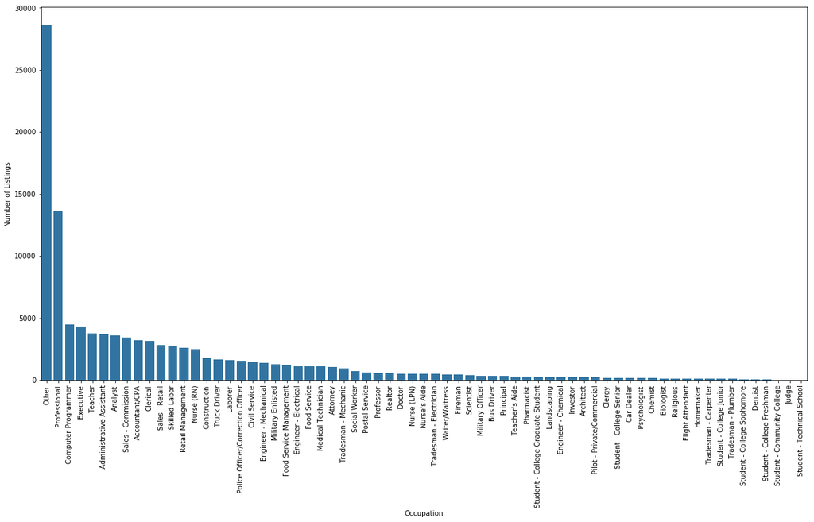

```python
#univariate plot of occupation
plt.figure(figsize=(20,10))
base_color = sb.color_palette()[0]
cat_order = prosperLoanData['Occupation'].value_counts().index
sb.countplot(data = prosperLoanData , x = 'Occupation', color = base_color, order = cat_order)
plt.xlabel('Occupation')
plt.ylabel('Number of Listings')
plt.xticks(rotation=90);
```

```python
prosperLoanData['Occupation'].value_counts()
```

```
Other                                 21317
Professional                          10542
Executive                              3468
Computer Programmer                    3236
Teacher                                2888
Analyst                                2735
Administrative Assistant               2708
Accountant/CPA                         2574
Sales - Commission                     2350
Skilled Labor                          2180
Nurse (RN)                             2159
Clerical                               2116
Sales - Retail                         2029
Retail Management                      2001
Truck Driver                           1366
Construction                           1326
Police Officer/Correction Officer      1277
Laborer                                1217
Civil Service                          1139
Engineer - Mechanical                  1135
Food Service Management                1005
Engineer - Electrical                   900
Medical Technician                      891
Attorney                                866
Food Service                            837
Military Enlisted                       824
Tradesman - Mechanic                    797
Social Worker                           575
Postal Service                          487
Professor                               452
                                      ...
Principal                               262
Realtor                                 252
Military Officer                        252
Bus Driver                              250
Pharmacist                              225
Investor                                201
Teacher's Aide                          200
Engineer - Chemical                     176
Landscaping                             172
Clergy                                  157
Pilot - Private/Commercial              153
Architect                               149
Car Dealer                              143
Psychologist                            118
Student - College Graduate Student      112
Chemist                                 109
Biologist                                95
Religious                                93
Flight Attendant                         87
Tradesman - Carpenter                    85
Tradesman - Plumber                      74
Student - College Senior                 70
Homemaker                                57
Dentist                                  56
Student - College Junior                 27
Judge                                    22
Student - College Freshman               17
Student - College Sophomore              16
Student - Community College              10
Student - Technical School                2
Name: Occupation, Length: 67, dtype: int64
```

Majority of the borrowers put their occupation as "Other". It's not helpful and it's affected the distribution accuracy. This also the same with the "Professional."

I'm curious what States the greatest number of loans.

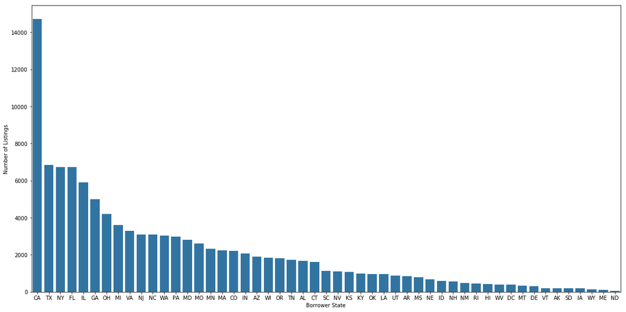

```python
#univariate plot of borrower state
plt.figure(figsize=(20,10))
base_color = sb.color_palette()[0]
cat_order = prosperLoanData['BorrowerState'].value_counts().index
sb.countplot(data = prosperLoanData , x = 'BorrowerState', color = base_color, order = cat_order)
plt.xlabel('Borrower State')
plt.ylabel('Number of Listings');
```

```python
prosperLoanData['BorrowerState'].value_counts()
```

```
CA    10761
NY     5844
TX     5634
FL     5406
IL     4264
OH     3373
GA     3347
VA     2779
NJ     2725
PA     2678
MI     2622
NC     2439
MD     2241
WA     2153
MA     1831
MO     1793
CO     1729
MN     1715
IN     1652
TN     1538
WI     1521
CT     1492
AZ     1357
OR     1214
AL     1187
NV     1024
SC      994
KY      888
KS      854
LA      841
AR      769
OK      732
MS      675
NE      555
UT      522
NH      443
RI      409
ID      403
HI      342
NM      331
DC      328
WV      310
DE      267
MT      221
SD      189
VT      171
AK      167
WY      123
Name: BorrowerState, dtype: int64
```

The top 5 highest listings are in CA, TX, NY, FL, and IL but, CA dominates all. Geographically, the prosper listings distribution are similar to the US population.

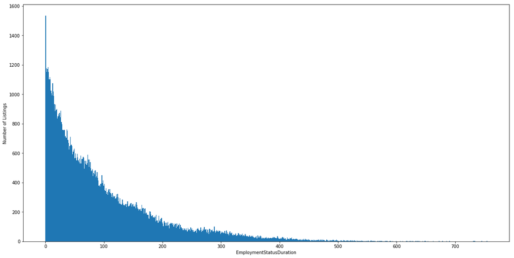

```python
#univariate plot of employment status duration
plt.figure(figsize=(20,10))
bins = np.arange(0, prosperLoanData['EmploymentStatusDuration'].max()+1, 1)
plt.hist(prosperLoanData['EmploymentStatusDuration'], bins = bins)
plt.xlabel('EmploymentStatusDuration')
plt.ylabel('Number of Listings');
```

```python
prosperLoanData['EmploymentStatusDuration'].describe()
```

```
count    84834.000000
mean       103.055320
std         97.078884
min          0.000000
25%         30.000000
50%         74.000000
75%        148.000000
max        755.000000
Name: EmploymentStatusDuration, dtype: float64
```

The employment status duration shows positive skew with mean of 103 which is greater than median 74. More likely that more people are employed the shorter the duration.

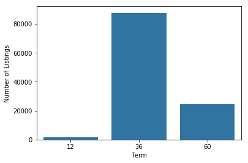

```python
#loan term
base_color = sb.color_palette()[0]
sb.countplot(data = prosperLoanData , x = 'Term', color = base_color)
plt.xlabel('Term')
plt.ylabel('Number of Listings');
```

Majority of loan term is 36.

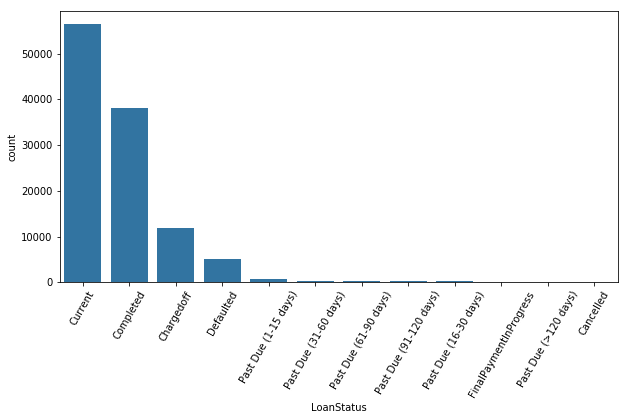

```python
#univariate plot of loan status
plt.figure(figsize=(10,5))
base_color = sb.color_palette()[0]
cat_order = prosperLoanData['LoanStatus'].value_counts().index
sb.countplot(data = prosperLoanData , x = 'LoanStatus', color = base_color, order = cat_order)
plt.xticks(rotation=60);
```

```python
prosperLoanData['LoanStatus'].value_counts()
```

```
Current                   56576
Completed                 38074
Chargedoff                11992
Defaulted                  5018
Past Due (1-15 days)        806
Past Due (31-60 days)       363
Past Due (61-90 days)       313
Past Due (91-120 days)      304
Past Due (16-30 days)       265
FinalPaymentInProgress      205
Past Due (>120 days)         16
Cancelled                     5
Name: LoanStatus, dtype: int64
```

The large majority of loans are either Current or Completed, although there is a large number of Defaulted(non-performing.)

### Discuss the distribution(s) of your variable(s) of interest. Were there any unusual points? Did you need to perform any transformations?

> Most of my cleanup efforts on re-ordering default factors levels to make more intuitive sense when displayed in a histogram. The major unusual point of distribution was the number of loans originated each quarter which exhibit the dip in early 2009. Some categorical plots I have to re-order by value counts, prosper rating levels from riskiest to less risky, and the loan origination quarter in chronological order.

### Of the features you investigated, were there any unusual distributions? Did you perform any operations on the data to tidy, adjust, or change the form of the data? If so, why did you do this?

> The monthly payment distribution skews towards to smaller monthly payments. There are very few payments above 1,000 dollars, and the payment >2k seems like a significant outlier. So, I re-plotted in a log scale and actually found there's couple of peaks. One peak from 100 to 300, and a second peak below 600. There is a jump in frequency at 400, rather than a smooth ramp down.

## Bivariate Exploration

I want to start to see the correlation present betwen features in the data.

```python
numeric_vars = ['LoanOriginalAmount', 'MonthlyLoanPayment', 'BorrowerRate', 'BorrowerAPR', 'DebtToIncomeRatio', 'CreditScoreRangeLower',
                'CreditScoreRangeUpper', 'StatedMonthlyIncome', 'EmploymentStatusDuration', 'ProsperRating (Alpha)', 'ProsperScore']
categoric_vars = ['LoanOriginationQuarter', 'ListingCategory', 'EmploymentStatus', 'IsBorrowerHomeowner', 'CreditGrade', 'IncomeRange',
                  'IncomeVerifiable', 'BorrowerState', 'Occupation', 'Term']
```

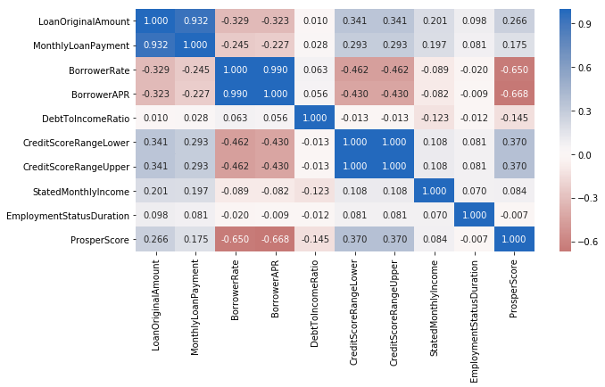

```python
#correlation plot of numeric variables
plt.figure(figsize = [10, 5])
sb.heatmap(prosperLoanData[numeric_vars].corr(), annot = True, fmt = '.3f',
           cmap = 'vlag_r', center = 0)
plt.show()
```

```python
#correlation plot of both numeric and categoric variables
all_vars = ['LoanOriginalAmount', 'MonthlyLoanPayment', 'BorrowerRate', 'BorrowerAPR', 'DebtToIncomeRatio', 'CreditScoreRangeLower',
                'CreditScoreRangeUpper', 'StatedMonthlyIncome', 'EmploymentStatusDuration', 'ProsperRating (Alpha)', 'ProsperScore',
            'LoanOriginationQuarter', 'ListingCategory', 'EmploymentStatus', 'IsBorrowerHomeowner', 'CreditGrade', 'IncomeRange',
                  'IncomeVerifiable', 'BorrowerState', 'Occupation', 'Term']
```

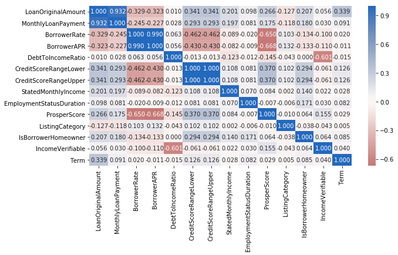

```python
# correlation plot of all variables
plt.figure(figsize = [10, 5])
sb.heatmap(prosperLoanData[all_vars].corr(), annot = True, fmt = '.3f',
           cmap = 'vlag_r', center = 0)
plt.show()
```

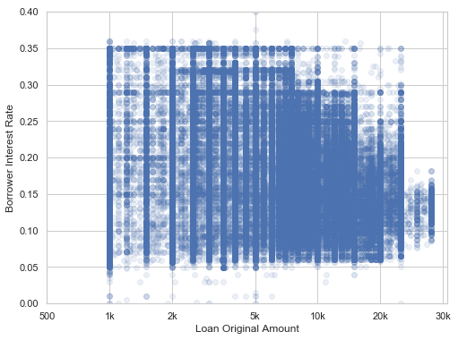

```python
#bivariate plot of loan original amount vs borrower interest rate
plt.figure(figsize = [8, 6])
sns.set(style="whitegrid")
plt.scatter(data = prosperLoanData, x = 'LoanOriginalAmount', y = 'BorrowerRate', alpha = 1/10)
plt.ylim([0, 0.4])
plt.ylabel('Borrower Interest Rate')
plt.xscale('log')
plt.xticks([500, 1e3, 2e3, 5e3, 1e4, 2e4, 4e4], ['500', '1k', '2k', '5k', '10k', '20k', '30k'])
plt.xlabel('Loan Original Amount')
plt.show()
```

The high interest rates > 20% mostly applied on the smaller loans, expected lower interest rate on larger loans.

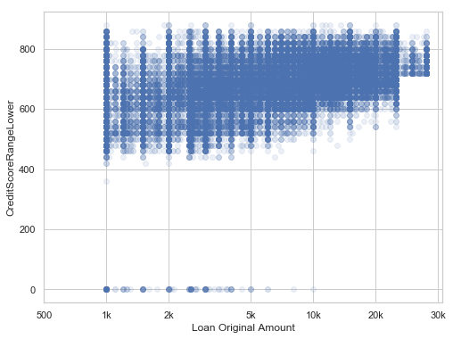

```python
#bivariate plot of loan original amount vs crredit score
plt.figure(figsize = [8, 6])
sns.set(style="whitegrid")
plt.scatter(data = prosperLoanData, x = 'LoanOriginalAmount', y = 'CreditScoreRangeLower', alpha = 1/10)

plt.ylabel('CreditScoreRangeLower')
plt.xscale('log')
plt.xticks([500, 1e3, 2e3, 5e3, 1e4, 2e4, 4e4], ['500', '1k', '2k', '5k', '10k', '20k', '30k'])
plt.xlabel('Loan Original Amount')
plt.show()
```

The larger the loan, the higher the credit score. I'm only checking the credit score range lower since the upper range has very similar distribution to lower range but 19 points higher.

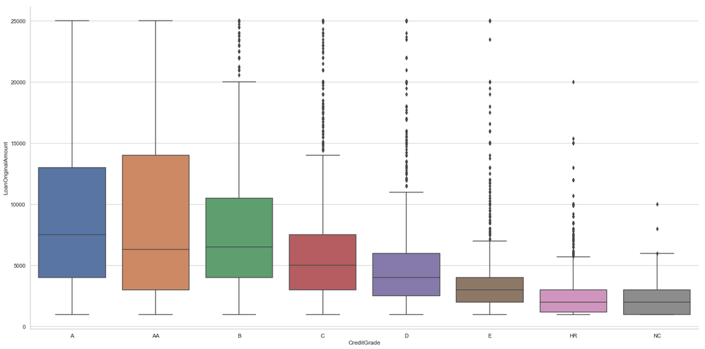

```python
#bivariate plot of loan original amount vs credit grade in an order categorical type high grade to low grade
grade = ['A', 'AA', 'B', 'C', 'D', 'E', 'HR','NC']
grade_cat = pd.api.types.CategoricalDtype(ordered = True, categories = grade)
prosperLoanData['CreditGrade'] = prosperLoanData['CreditGrade'].astype(grade_cat)

prosperLoanData = prosperLoanData.loc[prosperLoanData['CreditGrade'].isin(['A', 'AA', 'B', 'C', 'D', 'E', 'HR','NC'])]

sns.set(style="whitegrid")
sns.catplot(x='CreditGrade', y='LoanOriginalAmount', kind="box", data=prosperLoanData, height=10, aspect=2);
```

This demonstrates the larger loan amounts have better credit grades (A-AA-B).

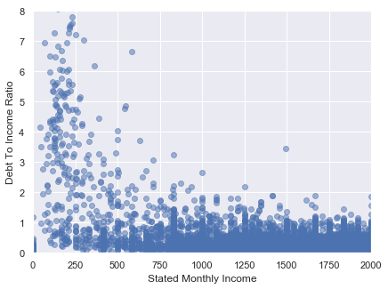

```python
#bivariate plot of stated monthly income vs debt to income ratio
plt.figure(figsize = [15,5])
sns.set(style="darkgrid")
plt.subplot(1,2,1)
sb.regplot(data = prosperLoanData, x = 'StatedMonthlyIncome', y = 'DebtToIncomeRatio', fit_reg = False,
          x_jitter = 0.01, y_jitter = 0.01, scatter_kws = {'alpha':1/2})
plt.xlim(0, 2000)
plt.ylim(0, 8)
plt.xlabel('Stated Monthly Income')
plt.ylabel('Debt To Income Ratio');
```

Most of the borrowers with lower monthly income towards below $500 have higher debt to income ratio. It seems they take on larger loans.

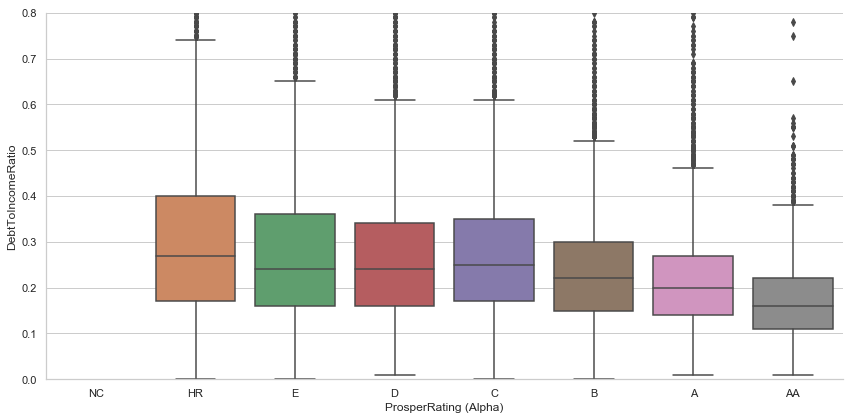

```python
#bivariate plot of debt to income ratio vs prosper rating in order categorical type from riskiest to less risky
pros_rate = ['NC', 'HR', 'E', 'D', 'C', 'B', 'A','AA']
rate_cat = pd.api.types.CategoricalDtype(ordered = True, categories = pros_rate)
prosperLoanData['ProsperRating (Alpha)'] = prosperLoanData['ProsperRating (Alpha)'].astype(rate_cat)

prosperLoanData = prosperLoanData.loc[prosperLoanData['ProsperRating (Alpha)'].isin(['NC', 'HR', 'E', 'D', 'C', 'B', 'A','AA'])]

sns.set(style='whitegrid')
sns.catplot(x='ProsperRating (Alpha)', y='DebtToIncomeRatio', kind='box', data=prosperLoanData, height=6, aspect=2);
plt.ylim(0, 0.8);
```

While there appears to be some relationship between a low DTI ratio and a good Prosper Rating (AA, A, B), for riskier loans the mean DTI is roughly the same across the board. Clearly, other factors influence the Prosper rating.

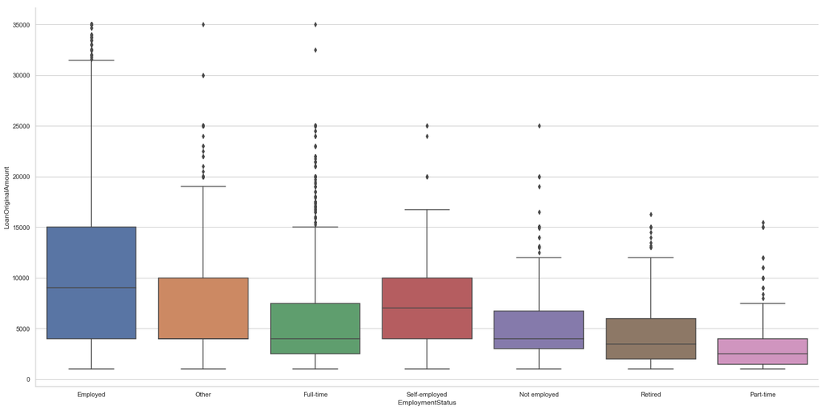

```python
#bivariate plot of employment status and loan original amount
sns.set(style="whitegrid")
sns.catplot(x='EmploymentStatus', y='LoanOriginalAmount', kind='box', data=prosperLoanData, height=10, aspect=2);
```

Interesting to see the self-employed is second highest with loan amount (not accounting the "Other".) Since personal loans for self-employed are harder to get, borrowers must have required something extra to convince the lender to approve a request for money.

```python
prosperLoanData['LoanOriginationQuarter'].value_counts()
```

```
Q4 2013    14450
Q1 2014    12172
Q3 2013     9180
Q2 2013     7099
Q3 2012     5632
Q2 2012     5061
Q1 2012     4435
Q4 2012     4425
Q4 2011     3913
Q1 2013     3616
Q3 2011     3093
Q2 2011     2478
Q1 2011     1744
Q4 2010     1579
Q2 2010     1518
Q4 2009     1417
Q3 2010     1256
Q1 2010     1226
Q3 2009      559
Q2 2009        0
Q4 2008        0
Q3 2008        0
Q2 2008        0
Q1 2008        0
Q4 2007        0
Q3 2007        0
Q2 2007        0
Q1 2007        0
Q4 2006        0
Q3 2006        0
Q2 2006        0
Q1 2006        0
Q4 2005        0
Name: LoanOriginationQuarter, dtype: int64
```